# IODS course project

# 4: Clustering and classification

```r
date()
```

```
## [1] "Tue Dec 12 03:39:27 2023"
```

```r
library(MASS)
library(corrplot)
library(tidyr)
```

## 2. Load and describe data

```r
# load the data
data("Boston")

# explore the dataset
dim(Boston)
```

```
## [1] 506  14
```

```r
str(Boston)
```

```
## 'data.frame':    506 obs. of  14 variables:
##  $ crim   : num  0.00632 0.02731 0.02729 0.03237 0.06905 ...
##  $ zn     : num  18 0 0 0 0 0 12.5 12.5 12.5 12.5 ...
##  $ indus  : num  2.31 7.07 7.07 2.18 2.18 2.18 7.87 7.87 7.87 7.87 ...
##  $ chas   : int  0 0 0 0 0 0 0 0 0 0 ...
##  $ nox    : num  0.538 0.469 0.469 0.458 0.458 0.458 0.524 0.524 0.524 0.524 ...
##  $ rm     : num  6.58 6.42 7.18 7 7.15 ...
##  $ age    : num  65.2 78.9 61.1 45.8 54.2 58.7 66.6 96.1 100 85.9 ...
##  $ dis    : num  4.09 4.97 4.97 6.06 6.06 ...
##  $ rad    : int  1 2 2 3 3 3 5 5 5 5 ...
##  $ tax    : num  296 242 242 222 222 222 311 311 311 311 ...
##  $ ptratio: num  15.3 17.8 17.8 18.7 18.7 18.7 15.2 15.2 15.2 15.2 ...
##  $ black  : num  397 397 393 395 397 ...
##  $ lstat  : num  4.98 9.14 4.03 2.94 5.33 ...
##  $ medv   : num  24 21.6 34.7 33.4 36.2 28.7 22.9 27.1 16.5 18.9 ...
```

Data description: There are 506 observations and 14 variables, which, according to the str, seem to all include numerical data. A brief description of the data can be found [here](https://stat.ethz.ch/R-manual/R-devel/library/MASS/html/Boston.html). For me this kind of data is quite foreign and may be difficult to understand, since also variable descriptions look very short in the source, but I try to interpret the variables somehow.

The data is titled as “Housing Values in Suburbs of Boston” and I guess that the 14 variables describe the housing values of 506 suburbs in Boston. It seems for me that some variables, such as black (1000(Bk−0.63)^2 where BkBk is the proportion of blacks by town) and lstat (lower status of the population (percent), tax (full-value property-tax rate per $10,000), zn (proportion of residential land zoned for lots over 25,000 sq.ft.), rm (average number of rooms per dwelling), age (proportion of owner-occupied units built prior to 1940), and medv (median value of owner-occupied homes in $1000s) describe the population or wealth of people living in the area. Some others, such as crim (per capita crime rate by town), indus (proportion of non-retail business acres per town), dis (weighted mean of distances to five Boston employment centres), rad (index of accessibility to radial highways), ptratio (pupil-teacher ratio by town) could describe possibilities to work and earn living. Nox (nitrogen oxides concentration (parts per 10 million) may indicate the rate of (private) motor vehicle use in the area. The chas (Charles River dummy variable (= 1 if tract bounds river; 0 otherwise)) seems to define roughly the location of suburb in relation to the river.

## 3. Graphical overview, summaries and relationships of the variables

### Numerical summaries

```r
#summaries
summary(Boston)
```

```
##       crim                zn             indus            chas
##  Min.   : 0.00632   Min.   :  0.00   Min.   : 0.46   Min.   :0.00000
##  1st Qu.: 0.08205   1st Qu.:  0.00   1st Qu.: 5.19   1st Qu.:0.00000
##  Median : 0.25651   Median :  0.00   Median : 9.69   Median :0.00000
##  Mean   : 3.61352   Mean   : 11.36   Mean   :11.14   Mean   :0.06917
##  3rd Qu.: 3.67708   3rd Qu.: 12.50   3rd Qu.:18.10   3rd Qu.:0.00000
##  Max.   :88.97620   Max.   :100.00   Max.   :27.74   Max.   :1.00000
##       nox               rm             age              dis
##  Min.   :0.3850   Min.   :3.561   Min.   :  2.90   Min.   : 1.130
##  1st Qu.:0.4490   1st Qu.:5.886   1st Qu.: 45.02   1st Qu.: 2.100
##  Median :0.5380   Median :6.208   Median : 77.50   Median : 3.207
##  Mean   :0.5547   Mean   :6.285   Mean   : 68.57   Mean   : 3.795
##  3rd Qu.:0.6240   3rd Qu.:6.623   3rd Qu.: 94.08   3rd Qu.: 5.188
##  Max.   :0.8710   Max.   :8.780   Max.   :100.00   Max.   :12.127
##       rad              tax           ptratio          black
##  Min.   : 1.000   Min.   :187.0   Min.   :12.60   Min.   :  0.32
##  1st Qu.: 4.000   1st Qu.:279.0   1st Qu.:17.40   1st Qu.:375.38
##  Median : 5.000   Median :330.0   Median :19.05   Median :391.44
##  Mean   : 9.549   Mean   :408.2   Mean   :18.46   Mean   :356.67
##  3rd Qu.:24.000   3rd Qu.:666.0   3rd Qu.:20.20   3rd Qu.:396.23
##  Max.   :24.000   Max.   :711.0   Max.   :22.00   Max.   :396.90
##      lstat            medv
##  Min.   : 1.73   Min.   : 5.00
##  1st Qu.: 6.95   1st Qu.:17.02
##  Median :11.36   Median :21.20
##  Mean   :12.65   Mean   :22.53
##  3rd Qu.:16.95   3rd Qu.:25.00
##  Max.   :37.97   Max.   :50.00
```

```r
table(Boston$chas)
```

```
##
##   0   1
## 471  35
```

Interpretation of summaries: Variables have very different ranges of numeric values. Based on differences in means and medians of the same variables I would not expect to find all of the variables to be normally distributed (as many of the means and medians differ quite much from each other), but it can be better evaluated from the next figures. Only one variable, chas, looks categorical, as expected. According to table, most of the suburbs are not located in the immediate vicinity of the river, if I have understood right.

### Graphical description of variables and their relationships

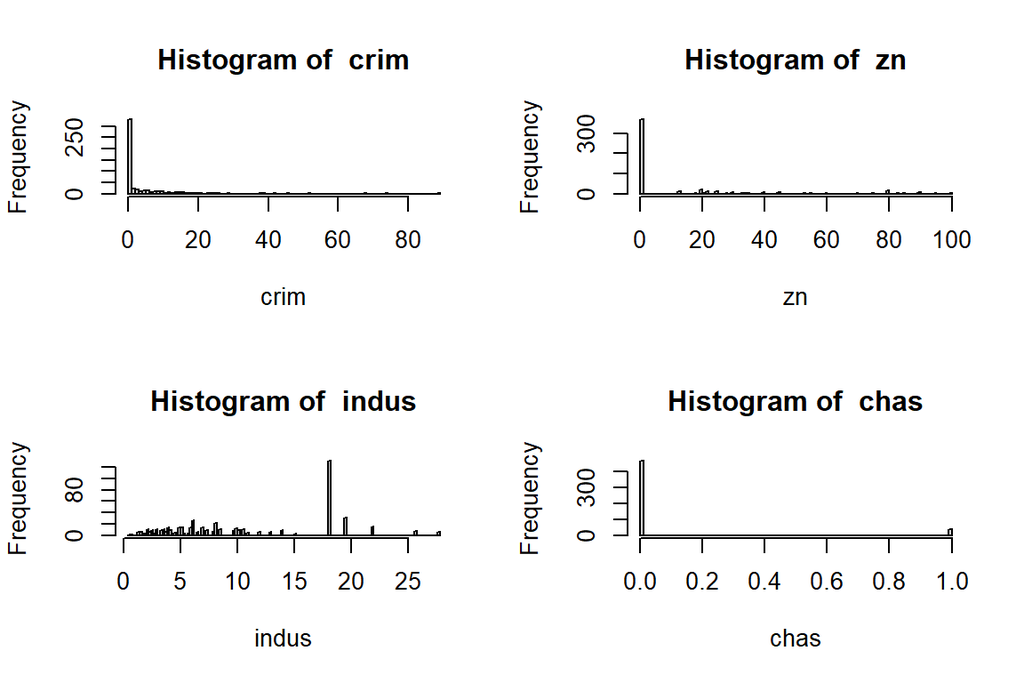

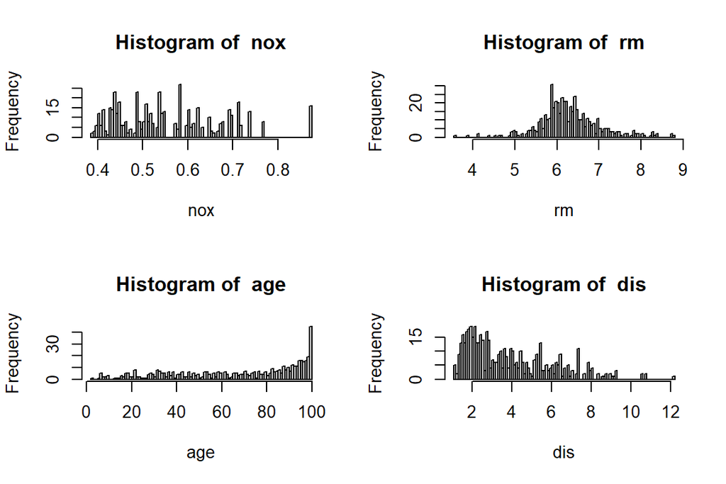

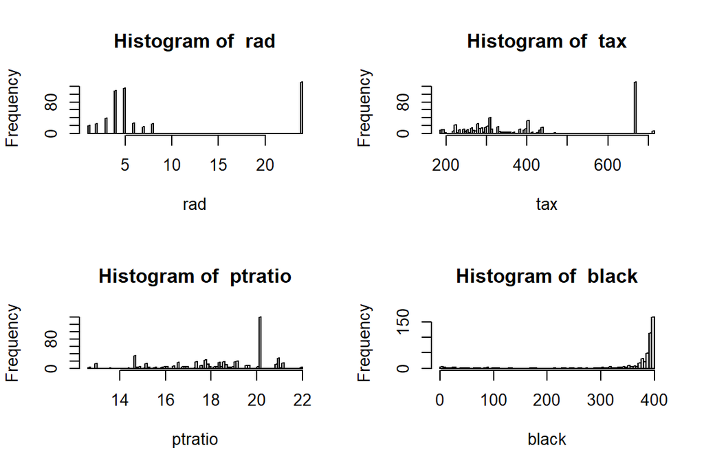

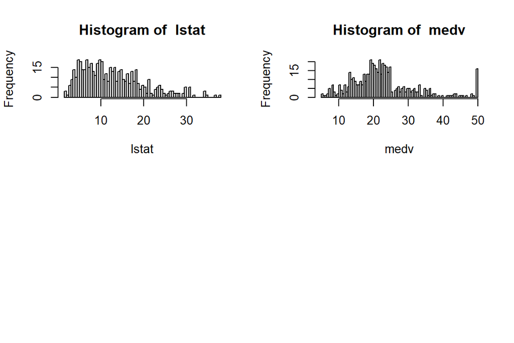

```r
#BAsic histograms of all continuous variables created in for loop
par(mfrow = c(2, 2))

for (i in c(1:14)){
  hist(Boston[,i], main = paste("Histogram of ", colnames(Boston)[i]), xlab = paste(colnames(Boston)[i]), breaks = 100, plot = T)
}
```

Interpretation of variable histograms: Only variables which histograms resemble normal distribution are rm, dis, lstat and medv, from which dis, lstat and medv are skewed, and at least medv and dis seem to have some outliers. But I’m not sure if any of these are expected to follow normal distribution and for clustering it may not matter. For most of the other variables, excluding nox and categorical chas variable, the values seem to be weighted towards either extreme of the distribution. Smaller frequences of other values are observed too, except rad and tax, where I can see quite clear gap between smaller values and very high values.